# Лабораторная работа №1

Структура документа LaTeX

18 декабря 2025 - Мунтаха Сидратул

Российский университет дружбы народов, Москва, Россия

2025

# Цель работы

## Основная цель

Изучение базовой структуры LaTeX-документа и принципов его компиляции в PDF-файл, а также освоение основных элементов форматирования текста, структурирования документа и использования математического режима.

# Подготовка окружения

## Проверка установки LaTeX

Перед началом работы была выполнена проверка установленного дистрибутива LaTeX.

Использовались: - Windows PowerShell  
- менеджер пакетов Chocolatey  
- дистрибутив TeX Live 2025

Проверка версии `pdflatex` подтвердила корректную установку системы.

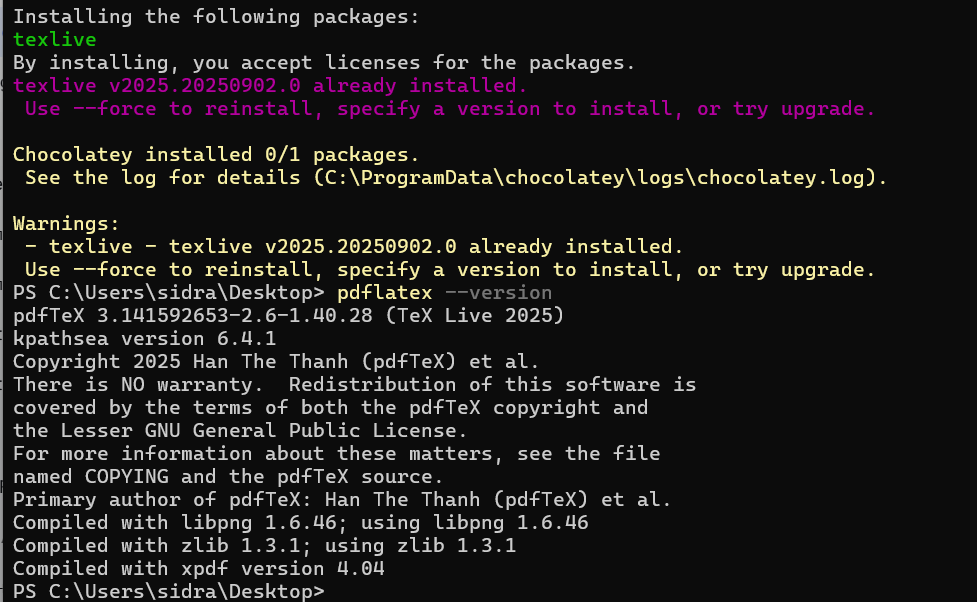

Проверка установки TeX Live

# Первый LaTeX-документ

## Создание файла first.tex

Был создан минимальный LaTeX-документ со следующими элементами:

- класс документа `article`;
- пакет `fontenc` с кодировкой `T1`;
- тело документа между `\begin{document}` и `\end{document}`.

## Компиляция first.tex

Компиляция выполнена с помощью `pdflatex`.

В процессе: - загружены стандартные файлы класса `article`; - автоматически созданы вспомогательные файлы; - выполнена генерация шрифтов.

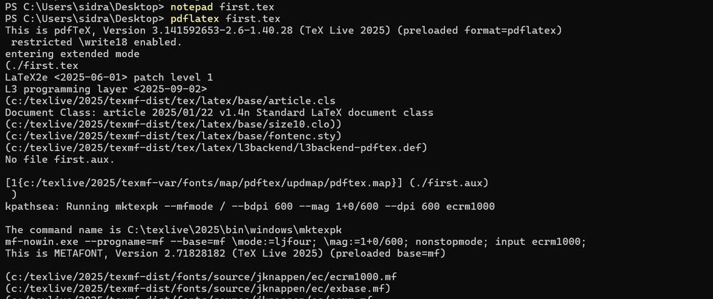

Компиляция first.tex

## Результат first.pdf

# Работа с текстом

## Абзацы и пробелы

В файле `exercise1.tex` были проверены:

- формирование нескольких абзацев;
- обработка множественных пробелов;
- использование пустых строк для разделения текста.

## Жёсткие пробелы и спецсимволы

Дополнительно продемонстрированы:

- жёсткие пробелы `~`;
- экранирование специальных символов (`$`, `%`, `#`, `_`);
- применение полужирного и курсивного начертания.

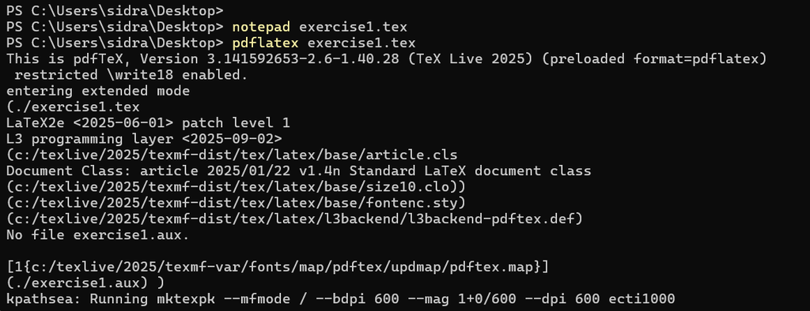

Компиляция exercise1.tex

## Результат exercise1.pdf

PDF-файл демонстрирует корректное форматирование текста и специальных символов.

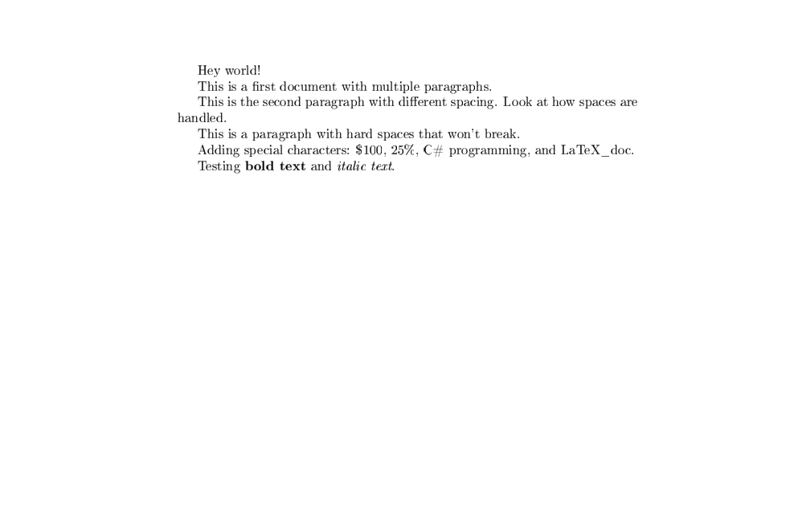

Результат exercise1.pdf

# Структура документа

## Разделы и подразделы

Для изучения структуры документа был создан файл `structure.tex`, содержащий:

- разделы `\section`;
- подразделы `\subsection`;
- несколько абзацев текста.

## Сноски и нумерация

В документе также использовалась команда `\footnote`, а нумерация разделов формировалась автоматически.

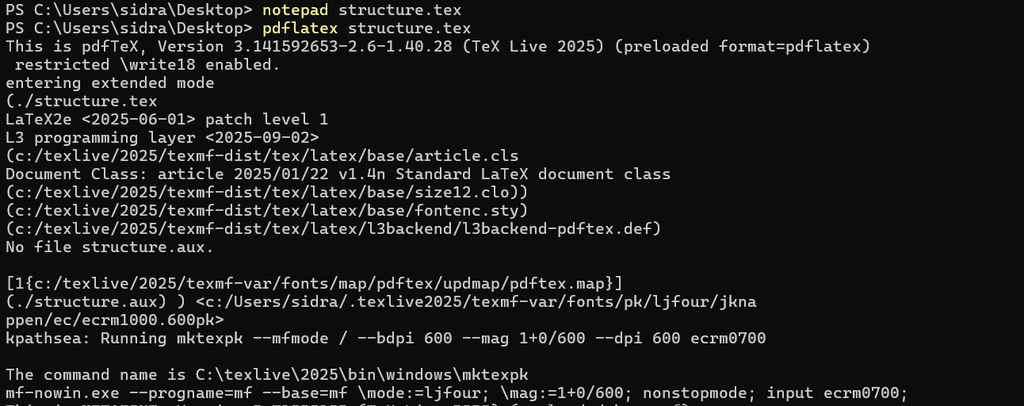

Компиляция structure.tex

## Результат structure.pdf

В PDF-документе наглядно представлены:

- иерархия разделов;
- автоматическая нумерация;
- корректное оформление сносок.

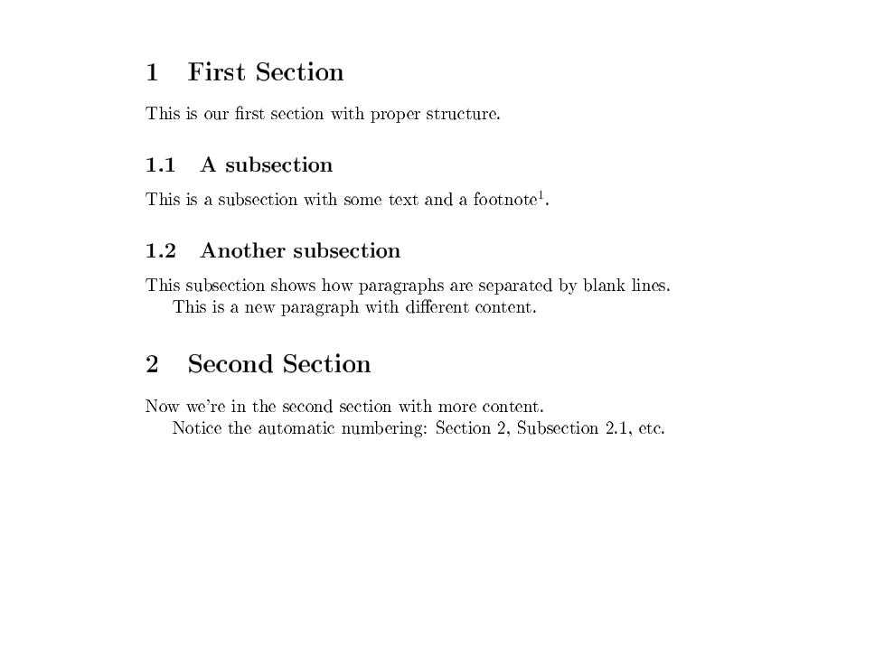

Результат structure.pdf

# Математический режим

## Базовые примеры (math1)

В документе `math1.pdf` продемонстрированы:

- inline-формулы;
- display-формулы;
- индексы;
- греческие буквы.

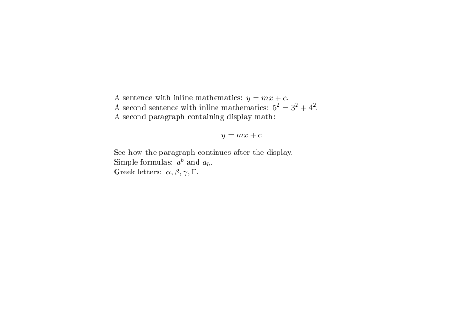

Математический режим LaTeX

## Расширенные возможности (math2)

В документе `math2.pdf` использован пакет **amsmath**, что позволило реализовать:

- нумерованные уравнения;
- интегралы;
- выравнивание многострочных формул.

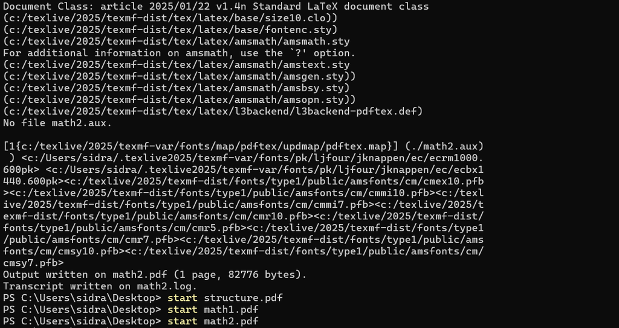

Компиляция math2.tex

## Результат math2.pdf

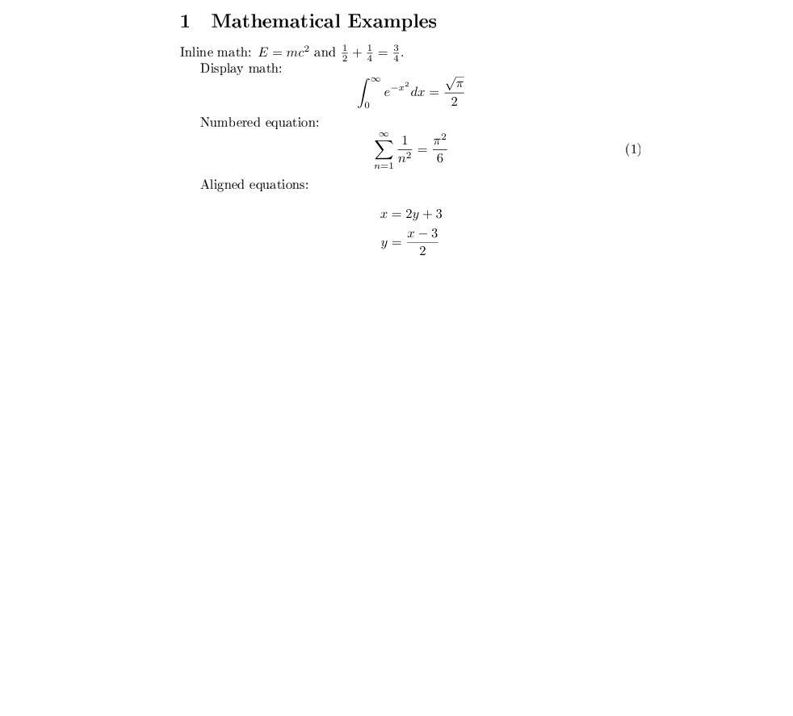

Результат math2.pdf

# Итоги работы

## Вывод

В ходе лабораторной работы были освоены:

- структура LaTeX-документа и его основные элементы;
- процесс компиляции `.tex`-файлов в PDF;
- работа с текстом, абзацами и специальными символами;
- структурирование документа с помощью разделов и сносок;
- основы математического режима LaTeX;
- возможности пакета **amsmath**.

LaTeX показал себя как мощный и гибкий инструмент для подготовки научных и технических документов.